# Secondary Outcome: Raw ADRI

Nancy Briggs & Gordana Popovic

2024-02-14

## rawadri

Raw ADRI does not have any missing values at baseline. N=6104

```r
# read in functions and data
source("functions.R")
myb_dat <- read.csv(paste0("../../Data/",params$data,".csv"))
```

## Data summary

confirming Ns.

```r
# commented out because the N function is not excluding missing observations
# myb_dat %>%
#   group_by(.dots = lapply(params$predictors, as.symbol)) %>%
#   summarize_at(.vars = params$response, .funs = list(Mean = mean, Sd = sd, N_obs = ~length(.)), na.rm=T)


myb_dat %>%
  group_by(rc_trial_time) %>%
  summarise(cn = sum(!is.na(rawadri)))
```

```
## # A tibble: 4 x 2
##   rc_trial_time    cn
##           <int> <int>
## 1             1  6104
## 2            10  3788
## 3            11  3373
## 4            12  3458
```

```r
myb_dat %>%
  group_by(group_type_id,rc_trial_time) %>%
  summarise(
            cn = sum(!is.na(rawadri)), cmean=mean(rawadri, na.rm=T),
            csd=sd(cleanadri, na.rm=T))
```

```
## # A tibble: 8 x 5
## # Groups:   group_type_id [2]
##   group_type_id rc_trial_time    cn  cmean   csd
##           <int>         <int> <int>  <dbl> <dbl>
## 1             1             1  3053 -2.07   7.84
## 2             1            10  2226 -1.83   8.58
## 3             1            11  1979 -0.845  8.81
## 4             1            12  2039  0.320  9.30
## 5             2             1  3051 -2.01   7.91
## 6             2            10  1562 -2.35   8.32
## 7             2            11  1394 -1.76   8.47
## 8             2            12  1419 -0.660  8.93
```

```r
# if want to run
if(!params$final){

  # run models
  fitted_mods <- MYB_fit(params$response, params$predictors,
                       params$covariates, params$id, myb_dat, times = plannedtimes)
  # save models
  save(fitted_mods,file = paste0("../../Results/Prelim/",params$response))

} else {
  load(file = paste0("../../Results/Prelim/",params$response))
}
```

```r
#plot models

if(!params$final){
  lapply(fitted_mods, plot, form = cond)
}
```

```r
#check summary is okay

if(!params$final){
  lapply(fitted_mods, summary)
}
```

### Results

```r
if(!params$final){

  # calculate CI
  res_tab = MYB_inf(fitted_mods, params$response)

  # save models
  write.csv(res_tab,file = paste0("../../Results/Prelim/",params$response,"_table.csv"), row.names = FALSE)



} else {
  res_tab <- read.csv(file = paste0("../../Results/Prelim/",params$response,"_table.csv"))


}
```

```r
res <- res_tab %>%
  transmute(response,
            adjusted,
            base_3yr_did = round(planned,3),
            LCL = round(asymp.LCL,3),
            UCL = round(asymp.UCL,3),
            zstat,
            pz,
            Chisq,
            `p.value` = ifelse (`p.value` < 0.001, "<0.001",paste("= ",round(`p.value`,3)))
)

res
```

```
##   response adjusted base_3yr_did    LCL    UCL  zstat       pz     Chisq
## 1  rawadri       No       -0.526 -0.884 -0.169 -2.884 =  0.004 13.138(3)
## 2  rawadri      Yes       -0.526 -0.880 -0.173 -2.921 =  0.003 13.932(3)
##    p.value
## 1 =  0.004
## 2 =  0.003
```

```r
evidence_unadj = ifelse(res_tab$p.value[1]<0.05, "evidence", "no evidence")
evidence_adj = ifelse(res_tab$p.value[2]<0.05, "evidence", "no evidence")
```

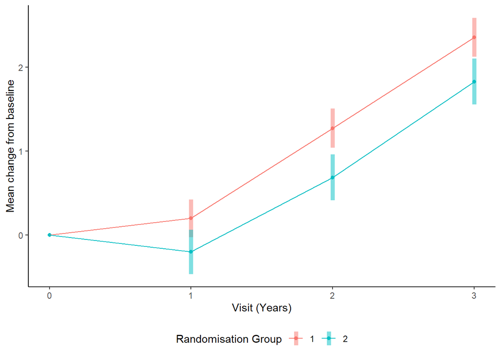

```r
# calculate all ems by time and group
group_time_ems <- emmeans(fitted_mods$unadj_mod,  ~ group_type_id + rc_trial_time)

# contrast to baseline by group
comp_to_baseline <- contrast(group_time_ems, rc_trial_time , "trt.vs.ctrl", by=  "group_type_id")

time_diff <- c(1:3)

to_bl_plot_df <- cbind(summary(comp_to_baseline)[,1:3],
                       confint(comp_to_baseline)[,6:7],
                       `Visit (Years)` = rep(c(1:3), 2))
# add baseline 0
to_bl_plot_df[7:8,] <- NA
to_bl_plot_df$group_type_id[7:8] = c(1,2)
to_bl_plot_df$estimate[7:8] = c(0,0)
to_bl_plot_df$`Visit (Years)`[7:8] = 0


to_bl_plot_df %>%
  ggplot(aes(`Visit (Years)`, estimate,color=factor(group_type_id), group=factor(group_type_id))) +
  geom_point() +
  geom_line()+
  geom_linerange(aes(ymin=asymp.LCL, ymax=asymp.UCL), size=2, alpha=.5) +
  theme_classic() +
  ylab("Mean change from baseline") +
  scale_color_discrete(name="Randomisation Group")  +
   theme(legend.position = "bottom")
```

```r
ggsave(file = paste0(params$response,"_",params$data,"_plot.png"), width = 12, height = 8, units = "cm")



to_bl_plot_df %>%
  transmute(group_type_id, `Visit (Years)`,
         estimate,
         LCL = asymp.LCL, UCL = asymp.UCL) %>%
  arrange(`Visit (Years)`,group_type_id) %>%
write.csv(file = paste0(params$response,"_",params$data,"_plotdata.csv"), row.names = FALSE)
```

## Result

Covariates included in adjusted models:

- `myb_age`: Age at Baseline
- `myb_gender`: Reported gender
- `cl_edu_yrs`: Years of education

There are a total of 6104 participants included in the mixed model analysis.

A linear mixed model with a random effect for patient and fixed effects of time point, randomisation group and their interaction was run. An additional analysis including covariates of myb_age, myb_gender, cl_edu_yrs was run. **NOTE: baseline ADRI was not included as a covariate in these analyses.**

We report estimates of the group difference in the change from baseline to three years follow up with 95% confidence interval, and associated Z statistic and p-value. **Note: ADRI score is modelled without baseline standardisation, units of effect size are in the units of ADRI score.**

The unadjusted difference between randomisation groups of change from baseline to three year follow up was -0.526 ( 95%CI: -0.884- -0.169,Z=-2.884, p= 0.004) .

The difference between randomisation groups of change from baseline to three year follow up was -0.526 ( 95%CI: -0.88 - -0.173,Z=-2.921,p= 0.003) , adjusting for myb_age, myb_gender, cl_edu_yrs.

Analysis by Nancy Briggs and Gordana Popovic on 2024-02-14

From SAP: Unadjusted and adjusted analyses. A linear mixed model with fixed effects of treatment group, time and the interaction will be performed. A random effect for individual will be specified. Unadjusted and adjusted estimates of the group difference at 3 years along with p-values and 95% CIs will be reported. Adjusted analyses will include the same variables as indicated in the primary outcome analysis.